# Introduction to Patterns: a modeling tool dedicated to biological network modeling

Frédéric Bertrand and Myriam Maumy-Bertrand

Université de Strasbourg et CNRS,IRMA, labex IRMIA  
frederic.bertrand@utt.fr

2024-05-04

# Patterns: a modeling tool dedicated to biological network modeling

It allows for **single** or **joint modeling** of, for instance, genes and proteins. It is design to work with **patterned data**. Famous examples of problems related to patterned data are: * recovering **signals** in networks after a **stimulation** (cascade network reverse engineering), * analysing **periodic signals**.

- It starts with the **selection of the actors** that will be the used in the reverse engineering upcoming step. An actor can be included in that selection based on its **differential effects** (for instance gene expression or protein abundance) or on its **time course profile**.
- Wrappers for **actors clustering** functions and cluster analysis are provided.
- It also allows **reverse engineering** of biological networks taking into account the observed time course patterns of the actors. Interactions between clusters of actors can be set by the user. Any number of clusters can be activated at a single time.
- Many **inference functions** are provided with the `Patterns` package and dedicated to get **specific features** for the inferred network such as **sparsity**, **robust links**, **high confidence links** or **stable through resampling links**.
  - **lasso**, from the `lars` package
  - **lasso**, from the `glmnet` package. An unweighted and a weighted version of the algorithm are available
  - **spls**, from the `spls` package
  - **elasticnet**, from the `elasticnet` package
  - **stability selection**, from the `c060` package implementation of stability selection
  - **weighted stability selection**, a new weighted version of the `c060` package implementation of stability selection that I created for the package
  - **robust**, lasso from the `lars` package with light random Gaussian noise added to the explanatory variables
  - **selectboost**, from the `selectboost` package. The selectboost algorithm looks for the more stable links against resampling that takes into account the correlated structure of the predictors
  - **weighted selectboost**, a new weighted version of the `selectboost`.
- Some **simulation** and **prediction** tools are also available for cascade networks.
- Examples of use with microarray or RNA-Seq data are provided.

The weights are viewed as a penalty factors in the penalized regression model: it is a number that multiplies the lambda value in the minimization problem to allow differential shrinkage, [Friedman et al. 2010](https://web.stanford.edu/~hastie/Papers/glmnet.pdf), equation 1 page 3. If equal to 0, it implies no shrinkage, and that variable is always included in the model. Default is 1 for all variables. Infinity means that the variable is excluded from the model. Note that the weights are rescaled to sum to the number of variables.

Due to maximum size requirement for CRAN packages, most of the graphics of the vignette will be created when the code is run.

A word for those that have been using our seminal work, the `Cascade` package that we created several years ago and that was a very efficient network reverse engineering tool for cascade networks (Jung, N., Bertrand, F., Bahram, S., Vallat, L., and Maumy-Bertrand, M. (2014), https://doi.org/10.1093/bioinformatics/btt705, https://cran.r-project.org/package=Cascade, https://github.com/fbertran/Cascade and https://fbertran.github.io/Cascade/).

The `Patterns` package is more than (at least) a threeway major extension of the `Cascade` package :

- **any number of groups** can be used whereas in the `Cascade` package only 1 group for each timepoint could be created, which prevented the users to create homogeneous clusters of genes in datasets that featured more than a few dozens of genes.
- **custom** $F$ matrices shapes whereas in the `Cascade` package only 1 shape was provided:
  - interaction between groups
  - custom design of inner cells of the $F$ matrix
- the custom $F$ matrices allow to deal with **heteregeneous networks** with several kinds of actors such as mixing genes and proteins in a single network to perform **joint inference**.
- about **nine inference algorithms** are provided, whereas 1 (lasso) in `Cascade`.

Hence the `Patterns` package should be viewed more as a completely new modelling tools than as an extension of the `Cascade` package.

This website and these examples were created by F. Bertrand and M. Maumy-Bertrand.

## Installation

You can install the released version of Patterns from [CRAN](https://CRAN.R-project.org) with:

```r
install.packages("Patterns")
```

You can install the development version of Patterns from [github](https://github.com) with:

```r
devtools::install_github("fbertran/Patterns")
```

## Examples

### Data management

Import Cascade Data (repeated measurements on several subjects) from the CascadeData package and turn them into a omics array object. The second line makes sure the CascadeData package is installed.

```r
library(Patterns)
if(!require(CascadeData)){install.packages("CascadeData")}
data(micro_US)
micro_US<-as.omics_array(micro_US[1:100,],time=c(60,90,210,390),subject=6)
str(micro_US)
```

```
#> Formal class 'omics_array' [package "Patterns"] with 7 slots
#>   ..@ omicsarray: num [1:100, 1:24] 103.2 26 70.7 213.7 13.7 ...
#>   .. ..- attr(*, "dimnames")=List of 2
#>   .. .. ..$ : chr [1:100] "1007_s_at" "1053_at" "117_at" "121_at" ...
#>   .. .. ..$ : chr [1:24] "N1_US_T60" "N1_US_T90" "N1_US_T210" "N1_US_T390" ...
#>   ..@ name      : chr [1:100] "1007_s_at" "1053_at" "117_at" "121_at" ...
#>   ..@ gene_ID   : num 0
#>   ..@ group     : num 0
#>   ..@ start_time: num 0
#>   ..@ time      : num [1:4] 60 90 210 390
#>   ..@ subject   : num 6
```

Get a summay and plots of the data:

```r
summary(micro_US)
```

```
#>    N1_US_T60        N1_US_T90        N1_US_T210       N1_US_T390
#>  Min.   :  12.2   Min.   :  12.9   Min.   :   1.5   Min.   :  10.1
#>  1st Qu.: 177.7   1st Qu.: 198.7   1st Qu.: 189.0   1st Qu.: 196.7
#>  Median : 513.0   Median : 499.4   Median : 608.5   Median : 541.2
#>  Mean   :1386.6   Mean   :1357.7   Mean   :1450.4   Mean   :1331.2
#>  3rd Qu.:1912.3   3rd Qu.:1883.4   3rd Qu.:2050.2   3rd Qu.:1646.2
#>  Max.   :6348.4   Max.   :6507.3   Max.   :6438.5   Max.   :6351.4
#>    N2_US_T60        N2_US_T90        N2_US_T210       N2_US_T390
#>  Min.   :  16.7   Min.   :   3.4   Min.   :   5.5   Min.   :   6.1
#>  1st Qu.: 212.4   1st Qu.: 185.7   1st Qu.: 214.7   1st Qu.: 230.1
#>  Median : 584.1   Median : 501.5   Median : 596.0   Median : 601.8
#>  Mean   :1381.9   Mean   :1345.4   Mean   :1410.5   Mean   :1403.7
#>  3rd Qu.:1616.2   3rd Qu.:1830.5   3rd Qu.:2005.8   3rd Qu.:1901.7
#>  Max.   :6149.3   Max.   :6090.8   Max.   :6160.6   Max.   :6143.1
#>    N3_US_T60        N3_US_T90        N3_US_T210       N3_US_T390
#>  Min.   :   1.9   Min.   :  10.3   Min.   :   3.3   Min.   :   6.6
#>  1st Qu.: 187.4   1st Qu.: 194.6   1st Qu.: 177.8   1st Qu.: 222.6
#>  Median : 611.4   Median : 576.2   Median : 552.2   Median : 593.7
#>  Mean   :1365.4   Mean   :1381.2   Mean   :1310.1   Mean   :1427.1
#>  3rd Qu.:1855.2   3rd Qu.:2040.2   3rd Qu.:1784.5   3rd Qu.:2131.7
#>  Max.   :6636.6   Max.   :6515.5   Max.   :6530.4   Max.   :6177.2
#>    N4_US_T60        N4_US_T90        N4_US_T210       N4_US_T390
#>  Min.   :  20.2   Min.   :  15.6   Min.   :  19.8   Min.   :   9.3
#>  1st Qu.: 199.3   1st Qu.: 215.4   1st Qu.: 207.0   1st Qu.: 197.8
#>  Median : 610.8   Median : 614.0   Median : 544.9   Median : 590.7
#>  Mean   :1505.1   Mean   :1526.7   Mean   :1401.6   Mean   :1458.8
#>  3rd Qu.:2198.1   3rd Qu.:2168.9   3rd Qu.:1831.2   3rd Qu.:1984.8
#>  Max.   :6986.2   Max.   :7148.0   Max.   :6820.0   Max.   :6762.3
#>    N5_US_T60        N5_US_T90        N5_US_T210       N5_US_T390
#>  Min.   :   3.4   Min.   :  10.0   Min.   :  10.7   Min.   :  16.5
#>  1st Qu.: 213.2   1st Qu.: 209.8   1st Qu.: 202.0   1st Qu.: 208.2
#>  Median : 609.4   Median : 561.3   Median : 555.6   Median : 570.5
#>  Mean   :1498.2   Mean   :1424.8   Mean   :1394.1   Mean   :1435.3
#>  3rd Qu.:2008.7   3rd Qu.:1906.5   3rd Qu.:1923.9   3rd Qu.:1867.8
#>  Max.   :7268.2   Max.   :6857.8   Max.   :6574.0   Max.   :6896.6
#>    N6_US_T60        N6_US_T90        N6_US_T210       N6_US_T390
#>  Min.   :  13.0   Min.   :   6.6   Min.   :   3.8   Min.   :  14.4
#>  1st Qu.: 207.5   1st Qu.: 198.6   1st Qu.: 203.9   1st Qu.: 195.8
#>  Median : 516.2   Median : 530.6   Median : 578.0   Median : 580.0
#>  Mean   :1412.9   Mean   :1388.3   Mean   :1416.5   Mean   :1360.8
#>  3rd Qu.:2037.4   3rd Qu.:1889.8   3rd Qu.:2030.8   3rd Qu.:1872.6
#>  Max.   :6898.1   Max.   :6749.4   Max.   :6490.0   Max.   :6780.2
```

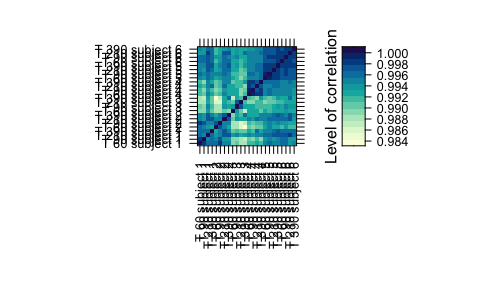

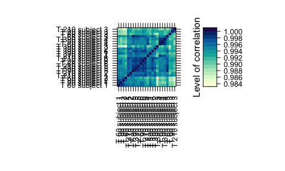

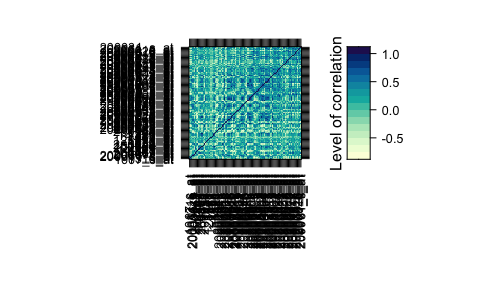

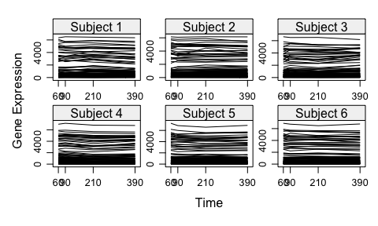

```r
plot(micro_US)
```

### Gene selection

There are several functions to carry out gene selection before the inference. They are detailed in the vignette of the package.

### Data simulation

Let’s simulate some cascade data and then do some reverse engineering.

We first design the F matrix for $T_i=4$ times and $Ngrp=4$ groups. The `Fmat`object is an array of sizes $(T_i,T-i,Ngrp^2)=(4,4,16)$.

```r
Ti<-4
Ngrp<-4

Fmat=array(0,dim=c(Ti,Ti,Ngrp^2))

for(i in 1:(Ti^2)){
  if(((i-1) %% Ti) > (i-1) %/% Ti){
    Fmat[,,i][outer(1:Ti,1:Ti,function(x,y){0<(x-y) & (x-y)<2})]<-1
    }
}
```

The `Patterns` function `CascadeFinit` is an utility function to easily define such an F matrix.

```r
Fbis=Patterns::CascadeFinit(Ti,Ngrp,low.trig=FALSE)
str(Fbis)
```

```
#>  num [1:4, 1:4, 1:16] 0 0 0 0 0 0 0 0 0 0 ...
```

Check if the two matrices `Fmat` and `Fbis` are identical.

```r
print(all(Fmat==Fbis))
```

```
#> [1] TRUE
```

End of F matrix definition.

```r
Fmat[,,3]<-Fmat[,,3]*0.2
Fmat[3,1,3]<-1
Fmat[4,2,3]<-1
Fmat[,,4]<-Fmat[,,3]*0.3
Fmat[4,1,4]<-1
Fmat[,,8]<-Fmat[,,3]
```

We set the seed to make the results reproducible and draw a scale free random network.

```r
set.seed(1)
Net<-Patterns::network_random(
  nb=100,
  time_label=rep(1:4,each=25),
  exp=1,
  init=1,
  regul=round(rexp(100,1))+1,
  min_expr=0.1,
  max_expr=2,
  casc.level=0.4
)
Net@F<-Fmat
str(Net)
```

```
#> Formal class 'omics_network' [package "Patterns"] with 6 slots
#>   ..@ omics_network: num [1:100, 1:100] 0 0 0 0 0 0 0 0 0 0 ...
#>   ..@ name         : chr [1:100] "gene 1" "gene 2" "gene 3" "gene 4" ...
#>   ..@ F            : num [1:4, 1:4, 1:16] 0 0 0 0 0 0 0 0 0 0 ...
#>   ..@ convF        : num [1, 1] 0
#>   ..@ convO        : num 0
#>   ..@ time_pt      : int [1:4] 1 2 3 4
```

Plot the simulated network.

```r
Patterns::plot(Net, choice="network")
```

If a gene clustering is known, it can be used as a coloring scheme.

```r
plot(Net, choice="network", gr=rep(1:4,each=25))
```

Plot the F matrix, for low dimensional F matrices.

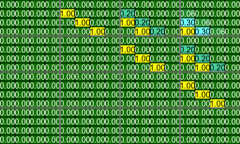

```r
plot(Net, choice="F")
```

Plot the F matrix using the `pixmap` package, for high dimensional F matrices.

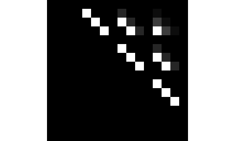

```r
plot(Net, choice="Fpixmap")
```

We simulate gene expression according to the network that was previously drawn

```r
set.seed(1)
M <- Patterns::gene_expr_simulation(
  omics_network=Net,
  time_label=rep(1:4,each=25),
  subject=5,
  peak_level=200,
  act_time_group=1:4)
str(M)
```

```
#> Formal class 'omics_array' [package "Patterns"] with 7 slots
#>   ..@ omicsarray: num [1:100, 1:20] 86.1 -146.8 228.3 505.1 -36.6 ...
#>   .. ..- attr(*, "dimnames")=List of 2
#>   .. .. ..$ : chr [1:100] "gene 1" "gene 2" "gene 3" "gene 4" ...
#>   .. .. ..$ : chr [1:20] "log(S/US) : P1T1" "log(S/US) : P1T2" "log(S/US) : P1T3" "log(S/US) : P1T4" ...
#>   ..@ name      : chr [1:100] "gene 1" "gene 2" "gene 3" "gene 4" ...
#>   ..@ gene_ID   : num 0
#>   ..@ group     : int [1:100] 1 1 1 1 1 1 1 1 1 1 ...
#>   ..@ start_time: num 0
#>   ..@ time      : int [1:4] 1 2 3 4
#>   ..@ subject   : num 5
```

Get a summay and plots of the simulated data:

```r
summary(M)
```

```
#>  log(S/US) : P1T1   log(S/US) : P1T2    log(S/US) : P1T3   log(S/US) : P1T4
#>  Min.   :-486.823   Min.   :-1962.641   Min.   :-1923.74   Min.   :-3391.76
#>  1st Qu.: -54.618   1st Qu.:  -23.300   1st Qu.:  -71.99   1st Qu.:  -58.69
#>  Median :  -8.319   Median :    0.000   Median :   -3.85   Median :    1.53
#>  Mean   :   8.799   Mean   :   22.064   Mean   :   20.72   Mean   :   19.82
#>  3rd Qu.:  69.340   3rd Qu.:    9.707   3rd Qu.:   33.00   3rd Qu.:   69.45
#>  Max.   : 942.229   Max.   : 1616.469   Max.   : 2899.61   Max.   : 3231.17
#>  log(S/US) : P2T1  log(S/US) : P2T2   log(S/US) : P2T3   log(S/US) : P2T4
#>  Min.   :-359.82   Min.   :-1126.13   Min.   :-600.757   Min.   :-797.980
#>  1st Qu.: -39.27   1st Qu.:  -14.15   1st Qu.: -49.998   1st Qu.: -73.700
#>  Median :  12.54   Median :    0.00   Median :  -7.749   Median :  -9.760
#>  Mean   :  21.35   Mean   :   20.02   Mean   :  23.579   Mean   :   8.361
#>  3rd Qu.:  73.02   3rd Qu.:   28.54   3rd Qu.:  67.216   3rd Qu.:  62.297
#>  Max.   : 451.61   Max.   :  946.22   Max.   :1869.077   Max.   : 935.321
#>  log(S/US) : P3T1   log(S/US) : P3T2    log(S/US) : P3T3    log(S/US) : P3T4
#>  Min.   :-430.696   Min.   :-1003.575   Min.   :-718.3926   Min.   :-1211.592
#>  1st Qu.: -65.939   1st Qu.:   -3.637   1st Qu.: -43.3783   1st Qu.:  -61.300
#>  Median :   1.392   Median :    0.000   Median :  -0.3233   Median :   -4.124
#>  Mean   :   4.032   Mean   :   11.431   Mean   :  19.7553   Mean   :    5.993
#>  3rd Qu.:  62.391   3rd Qu.:   36.945   3rd Qu.:  69.6650   3rd Qu.:   62.634
#>  Max.   : 514.510   Max.   :  752.066   Max.   :1497.5790   Max.   : 1296.563
#>  log(S/US) : P4T1   log(S/US) : P4T2     log(S/US) : P4T3    log(S/US) : P4T4
#>  Min.   :-451.370   Min.   :-1113.1785   Min.   :-1506.536   Min.   :-446.40
#>  1st Qu.: -44.107   1st Qu.:   -8.8769   1st Qu.:  -48.512   1st Qu.: -56.95
#>  Median :   7.193   Median :    0.0000   Median :    4.243   Median :   3.71
#>  Mean   :  16.034   Mean   :    0.9469   Mean   :  -28.544   Mean   :  28.74
#>  3rd Qu.:  62.840   3rd Qu.:   33.2306   3rd Qu.:   46.374   3rd Qu.:  64.89
#>  Max.   : 657.434   Max.   :  844.0070   Max.   :  694.220   Max.   :1368.62
#>  log(S/US) : P5T1   log(S/US) : P5T2  log(S/US) : P5T3    log(S/US) : P5T4
#>  Min.   :-747.865   Min.   :-862.59   Min.   :-1493.607   Min.   :-1420.740
#>  1st Qu.: -78.166   1st Qu.: -15.10   1st Qu.:  -59.853   1st Qu.:  -32.799
#>  Median :  -8.900   Median :   0.00   Median :   -2.776   Median :    4.008
#>  Mean   :  -7.693   Mean   :  66.20   Mean   :  -13.865   Mean   :  -12.332
#>  3rd Qu.:  45.926   3rd Qu.:  31.74   3rd Qu.:   40.324   3rd Qu.:   59.892
#>  Max.   : 960.419   Max.   :1899.57   Max.   :  770.655   Max.   :  489.916
```

```r
plot(M)
```

### Network inferrence

We infer the new network using subjectwise leave one out cross-validation (default setting): all measurements from the same subject are removed from the dataset). The inference is carried out with a general Fshape.

```r
Net_inf_P <- Patterns::inference(M, cv.subjects=TRUE)
```

```
#> We are at step :  1
#> Computing Group (out of 4) :
#>  1.........................
#>  2.........................
#>  3.........................
#>  4.........................
#> The convergence of the network is (L1 norm) : 0.01
#> We are at step :  2
#> Computing Group (out of 4) :
#>  1.........................
#>  2.........................
#>  3.........................
#>  4.........................
#> The convergence of the network is (L1 norm) : 0.00522
#> We are at step :  3
#> Computing Group (out of 4) :
#>  1.........................
#>  2.........................
#>  3.........................
#>  4.........................
#> The convergence of the network is (L1 norm) : 0.0034
#> We are at step :  4
#> Computing Group (out of 4) :
#>  1.........................
#>  2.........................
#>  3.........................
#>  4.........................
#> The convergence of the network is (L1 norm) : 0.00235
#> We are at step :  5
#> Computing Group (out of 4) :
#>  1.........................
#>  2.........................
#>  3.........................
#>  4.........................
#> The convergence of the network is (L1 norm) : 0.00181
#> We are at step :  6
#> Computing Group (out of 4) :
#>  1.........................
#>  2.........................
#>  3.........................
#>  4.........................
#> The convergence of the network is (L1 norm) : 0.00142
#> We are at step :  7
#> Computing Group (out of 4) :
#>  1.........................
#>  2.........................
#>  3.........................
#>  4.........................
#> The convergence of the network is (L1 norm) : 0.00117
#> We are at step :  8
#> Computing Group (out of 4) :
#>  1.........................
#>  2.........................
#>  3.........................
#>  4.........................
#> The convergence of the network is (L1 norm) : 0.00098
```

Plot of the inferred F matrix

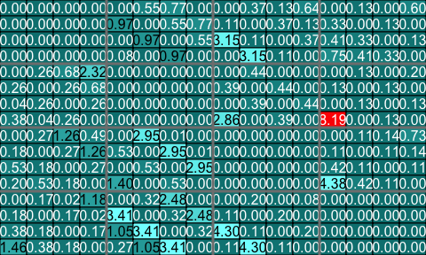

```r
plot(Net_inf_P, choice="F")
```

Heatmap of the inferred coefficients of the Omega matrix

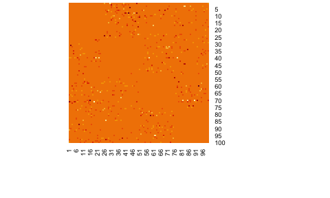

```r
stats::heatmap(Net_inf_P@omics_network, Rowv = NA, Colv = NA, scale="none", revC=TRUE)
```

Default values fot the $F$ matrices. The `Finit` matrix (starting values for the algorithm). In our case, the `Finit`object is an array of sizes $(T_i,T-i,Ngrp^2)=(4,4,16)$.

```r
Ti<-4;
ngrp<-4
nF<-ngrp^2
Finit<-array(0,c(Ti,Ti,nF))
              for(ii in 1:nF){
                if((ii%%(ngrp+1))==1){
                  Finit[,,ii]<-0
                } else {
                  Finit[,,ii]<-cbind(rbind(rep(0,Ti-1),diag(1,Ti-1)),rep(0,Ti))+rbind(cbind(rep(0,Ti-1),diag(1,Ti-1)),rep(0,Ti))
                }
              }
```

The `Fshape` matrix (default shape for `F` matrix the algorithm). Any interaction between groups and times are permitted except the retro-actions (a group on itself, or an action at the same time for an actor on another one).

```r
Fshape<-array("0",c(Ti,Ti,nF))
for(ii in 1:nF){
  if((ii%%(ngrp+1))==1){
    Fshape[,,ii]<-"0"
  } else {
    lchars <- paste("a",1:(2*Ti-1),sep="")
    tempFshape<-matrix("0",Ti,Ti)
    for(bb in (-Ti+1):(Ti-1)){
      tempFshape<-replaceUp(tempFshape,matrix(lchars[bb+Ti],Ti,Ti),-bb)
    }
    tempFshape <- replaceBand(tempFshape,matrix("0",Ti,Ti),0)
    Fshape[,,ii]<-tempFshape
  }
}
```

Any other form can be used. A “0” coefficient is missing from the model. It allows testing the best structure of an “F” matrix and even performing some significance tests of hypothses on the structure of the $F$ matrix.

The `IndicFshape` function allows to design custom F matrix for cascade networks with equally spaced measurements by specifying the zero and non zero $F_{ij}$ cells of the $F$ matrix. It is useful for models featuring several clusters of actors that are activated at the time. Let’s define the following indicatrix matrix (action of all groups on each other, which is not a possible real modeling setting and is only used as an example):

```r
TestIndic=matrix(!((1:(Ti^2))%%(ngrp+1)==1),byrow=TRUE,ngrp,ngrp)
TestIndic
```

```
#>       [,1]  [,2]  [,3]  [,4]
#> [1,] FALSE  TRUE  TRUE  TRUE
#> [2,]  TRUE FALSE  TRUE  TRUE
#> [3,]  TRUE  TRUE FALSE  TRUE
#> [4,]  TRUE  TRUE  TRUE FALSE
```

For that choice, we get those init and shape $F$ matrices.

```r
IndicFinit(Ti,ngrp,TestIndic)
```

```
#> , , 1
#>
#>      [,1] [,2] [,3] [,4]
#> [1,]    0    0    0    0
#> [2,]    0    0    0    0
#> [3,]    0    0    0    0
#> [4,]    0    0    0    0
#>
#> , , 2
#>
#>      [,1] [,2] [,3] [,4]
#> [1,]    0    0    0    0
#> [2,]    1    0    0    0
#> [3,]    1    1    0    0
#> [4,]    1    1    1    0
#>
#> , , 3
#>
#>      [,1] [,2] [,3] [,4]
#> [1,]    0    0    0    0
#> [2,]    1    0    0    0
#> [3,]    1    1    0    0
#> [4,]    1    1    1    0
#>
#> , , 4
#>
#>      [,1] [,2] [,3] [,4]
#> [1,]    0    0    0    0
#> [2,]    1    0    0    0
#> [3,]    1    1    0    0
#> [4,]    1    1    1    0
#>
#> , , 5
#>
#>      [,1] [,2] [,3] [,4]
#> [1,]    0    0    0    0
#> [2,]    1    0    0    0
#> [3,]    1    1    0    0
#> [4,]    1    1    1    0
#>
```

[output cut: 72 more lines]

```
#> , , 15
#>
#>      [,1] [,2] [,3] [,4]
#> [1,]    0    0    0    0
#> [2,]    1    0    0    0
#> [3,]    1    1    0    0
#> [4,]    1    1    1    0
#>
#> , , 16
#>
#>      [,1] [,2] [,3] [,4]
#> [1,]    0    0    0    0
#> [2,]    0    0    0    0
#> [3,]    0    0    0    0
#> [4,]    0    0    0    0
```

```r
IndicFshape(Ti,ngrp,TestIndic)
```

```
#> , , 1
#>
#>      [,1] [,2] [,3] [,4]
#> [1,] "0"  "0"  "0"  "0"
#> [2,] "0"  "0"  "0"  "0"
#> [3,] "0"  "0"  "0"  "0"
#> [4,] "0"  "0"  "0"  "0"
#>
#> , , 2
#>
#>      [,1] [,2] [,3] [,4]
#> [1,] "0"  "0"  "0"  "0"
#> [2,] "a1" "0"  "0"  "0"
#> [3,] "a2" "a1" "0"  "0"
#> [4,] "a3" "a2" "a1" "0"
#>
#> , , 3
#>
#>      [,1] [,2] [,3] [,4]
#> [1,] "0"  "0"  "0"  "0"
#> [2,] "a1" "0"  "0"  "0"
#> [3,] "a2" "a1" "0"  "0"
#> [4,] "a3" "a2" "a1" "0"
#>
#> , , 4
#>
#>      [,1] [,2] [,3] [,4]
#> [1,] "0"  "0"  "0"  "0"
#> [2,] "a1" "0"  "0"  "0"
#> [3,] "a2" "a1" "0"  "0"
#> [4,] "a3" "a2" "a1" "0"
#>
#> , , 5
#>
#>      [,1] [,2] [,3] [,4]
#> [1,] "0"  "0"  "0"  "0"
#> [2,] "a1" "0"  "0"  "0"
#> [3,] "a2" "a1" "0"  "0"
#> [4,] "a3" "a2" "a1" "0"
#>
```

[output cut: 72 more lines]

```
#> , , 15
#>
#>      [,1] [,2] [,3] [,4]
#> [1,] "0"  "0"  "0"  "0"
#> [2,] "a1" "0"  "0"  "0"
#> [3,] "a2" "a1" "0"  "0"
#> [4,] "a3" "a2" "a1" "0"
#>
#> , , 16
#>
#>      [,1] [,2] [,3] [,4]
#> [1,] "0"  "0"  "0"  "0"
#> [2,] "0"  "0"  "0"  "0"
#> [3,] "0"  "0"  "0"  "0"
#> [4,] "0"  "0"  "0"  "0"
```

Those $F$ matrices are lower diagonal ones to enforce that an observed value at a given time can only be predicted by a value that was observed in the past only (i.e. neither at the same moment or in the future).

The `plotF` is convenient to display F matrices. Here are the the displays of the three $F$ matrices we have just introduced.

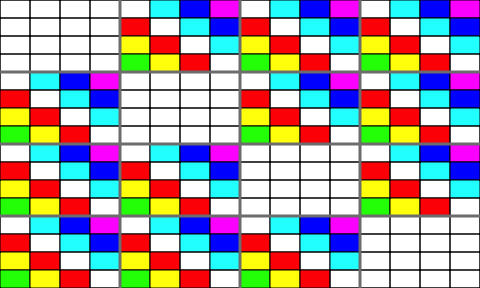

```r
plotF(Fshape,choice="Fshape")
```

```r
plotF(CascadeFshape(4,4),choice="Fshape")
```

```r
plotF(IndicFshape(Ti,ngrp,TestIndic),choice="Fshape")
```

We now fit the model with an $F$ matrix that is designed for cascade networks.

Specific Fshape

```r
Net_inf_P_S <- Patterns::inference(M, Finit=CascadeFinit(4,4), Fshape=CascadeFshape(4,4))
```

```
#> We are at step :  1
#> Computing Group (out of 4) :
#>  1
#>  2.........................
#>  3.........................
#>  4.........................
#> The convergence of the network is (L1 norm) : 0.0074
#> We are at step :  2
#> Computing Group (out of 4) :
#>  1
#>  2.........................
#>  3.........................
#>  4.........................
#> The convergence of the network is (L1 norm) : 0.00314
#> We are at step :  3
#> Computing Group (out of 4) :
#>  1
#>  2.........................
#>  3.........................
#>  4.........................
#> The convergence of the network is (L1 norm) : 0.0019
#> We are at step :  4
#> Computing Group (out of 4) :
#>  1
#>  2.........................
#>  3.........................
#>  4.........................
#> The convergence of the network is (L1 norm) : 0.00131
#> We are at step :  5
#> Computing Group (out of 4) :
#>  1
#>  2.........................
#>  3.........................
#>  4.........................
#> The convergence of the network is (L1 norm) : 0.00101
#> We are at step :  6
#> Computing Group (out of 4) :
#>  1
#>  2.........................
#>  3.........................
#>  4.........................
#> The convergence of the network is (L1 norm) : 0.00081
```

Plot of the inferred F matrix

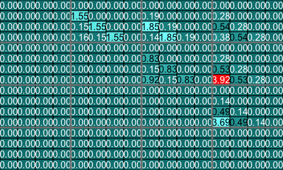

```r
plot(Net_inf_P_S, choice="F")
```

Heatmap of the coefficients of the Omega matrix of the network. They reflect the use of a special $F$ matrix. It is an example of an F matrix specifically designed to deal with cascade networks.

```r
stats::heatmap(Net_inf_P_S@omics_network, Rowv = NA, Colv = NA, scale="none", revC=TRUE)
```

There are many fitting functions provided with the `Patterns` package in order to search for **specific features** for the inferred network such as **sparsity**, **robust links**, **high confidence links** or **stable through resampling links**. :

- **LASSO**, from the `lars` package
- **LASSO2**, from the `glmnet` package. An unweighted and a weighted version of the algorithm are available
- **SPLS**, from the `spls` package
- **ELASTICNET**, from the `elasticnet` package
- **stability.c060**, from the `c060` package implementation of stability selection
- **stability.c060.weighted**, a new weighted version of the `c060` package implementation of stability selection
- **robust**, lasso from the `lars` package with light random Gaussian noise added to the explanatory variables
- **selectboost.weighted**, a new weighted version of the `selectboost` package implementation of the selectboost algorithm to look for the more stable links against resampling that takes into account the correlated structure of the predictors. If no weights are provided, equal weigths are for all the variables (=non weighted case).

```r
Net_inf_P_Lasso2 <- Patterns::inference(M, Finit=CascadeFinit(4,4), Fshape=CascadeFshape(4,4), fitfun="LASSO2")
```

```
#> We are at step :  1
#> Computing Group (out of 4) :
#>  1
#>  2.........................
#>  3.........................
#>  4.........................
#> The convergence of the network is (L1 norm) : 0.0069
#> We are at step :  2
#> Computing Group (out of 4) :
#>  1
#>  2.........................
#>  3.........................
#>  4.........................
#> The convergence of the network is (L1 norm) : 0.00229
#> We are at step :  3
#> Computing Group (out of 4) :
#>  1
#>  2.........................
#>  3.........................
#>  4.........................
#> The convergence of the network is (L1 norm) : 0.00153
#> We are at step :  4
#> Computing Group (out of 4) :
#>  1
#>  2.........................
#>  3.........................
#>  4.........................
#> The convergence of the network is (L1 norm) : 0.00114
#> We are at step :  5
#> Computing Group (out of 4) :
#>  1
#>  2.........................
#>  3.........................
#>  4.........................
#> The convergence of the network is (L1 norm) : 0.00086
```

Plot of the inferred F matrix

```r
plot(Net_inf_P_Lasso2, choice="F")
```

Heatmap of the coefficients of the Omega matrix of the network

```r
stats::heatmap(Net_inf_P_Lasso2@omics_network, Rowv = NA, Colv = NA, scale="none", revC=TRUE)
```

We create a weighting vector to perform weighted lasso inference.

```r
Weights_Net=slot(Net,"omics_network")
Weights_Net[Net@omics_network!=0]=.1
Weights_Net[Net@omics_network==0]=1000
```

```r
Net_inf_P_Lasso2_Weighted <- Patterns::inference(M, Finit=CascadeFinit(4,4), Fshape=CascadeFshape(4,4), fitfun="LASSO2", priors=Weights_Net)
```

```
#> We are at step :  1
#> Computing Group (out of 4) :
#>  1
#>  2.........................
#>  3.........................
#>  4.........................
#> The convergence of the network is (L1 norm) : 0.0075
#> We are at step :  2
#> Computing Group (out of 4) :
#>  1
#>  2.........................
#>  3.........................
#>  4.........................
#> The convergence of the network is (L1 norm) : 4e-04
```

Plot of the inferred F matrix

```r
plot(Net_inf_P_Lasso2_Weighted, choice="F")
```

Heatmap of the coefficients of the Omega matrix of the network

```r
stats::heatmap(Net_inf_P_Lasso2_Weighted@omics_network, Rowv = NA, Colv = NA, scale="none", revC=TRUE)
```

```r
Net_inf_P_SPLS <- Patterns::inference(M, Finit=CascadeFinit(4,4), Fshape=CascadeFshape(4,4), fitfun="SPLS")
```

```
#> We are at step :  1
#> Computing Group (out of 4) :
#>  1
#>  2.........................
#>  3.........................
#>  4.........................
#> The convergence of the network is (L1 norm) : 0.0075
#> We are at step :  2
#> Computing Group (out of 4) :
#>  1
#>  2.........................
#>  3.........................
#>  4.........................
#> The convergence of the network is (L1 norm) : 0.00229
#> We are at step :  3
#> Computing Group (out of 4) :
#>  1
#>  2.........................
#>  3.........................
#>  4.........................
#> The convergence of the network is (L1 norm) : 0.00164
#> We are at step :  4
#> Computing Group (out of 4) :
#>  1
#>  2.........................
#>  3.........................
#>  4.........................
#> The convergence of the network is (L1 norm) : 0.00123
#> We are at step :  5
#> Computing Group (out of 4) :
#>  1
#>  2.........................
#>  3.........................
#>  4.........................
#> The convergence of the network is (L1 norm) : 0.00104
#> We are at step :  6
#> Computing Group (out of 4) :
#>  1
#>  2.........................
#>  3.........................
#>  4.........................
#> The convergence of the network is (L1 norm) : 0.00088
```

Plot of the inferred F matrix

```r
plot(Net_inf_P_SPLS, choice="F")
```

Heatmap of the coefficients of the Omega matrix of the network

```r
stats::heatmap(Net_inf_P_SPLS@omics_network, Rowv = NA, Colv = NA, scale="none", revC=TRUE)
```

```r
Net_inf_P_ELASTICNET <- Patterns::inference(M, Finit=CascadeFinit(4,4), Fshape=CascadeFshape(4,4), fitfun="ELASTICNET")
```

```
#> We are at step :  1
#> Computing Group (out of 4) :
#>  1
#>  2.........................
#>  3.........................
#>  4.........................
#> The convergence of the network is (L1 norm) : 0.0074
#> We are at step :  2
#> Computing Group (out of 4) :
#>  1
#>  2.........................
#>  3.........................
#>  4.........................
#> The convergence of the network is (L1 norm) : 0.00396
#> We are at step :  3
#> Computing Group (out of 4) :
#>  1
#>  2.........................
#>  3.........................
#>  4.........................
#> The convergence of the network is (L1 norm) : 0.00284
#> We are at step :  4
#> Computing Group (out of 4) :
#>  1
#>  2.........................
#>  3.........................
#>  4.........................
#> The convergence of the network is (L1 norm) : 0.00215
#> We are at step :  5
#> Computing Group (out of 4) :
#>  1
#>  2.........................
#>  3.........................
#>  4.........................
#> The convergence of the network is (L1 norm) : 0.00168
#> We are at step :  6
#> Computing Group (out of 4) :
#>  1
#>  2.........................
#>  3.........................
```

[output cut: 8 more lines]

```
#> The convergence of the network is (L1 norm) : 0.00125
#> We are at step :  8
#> Computing Group (out of 4) :
#>  1
#>  2.........................
#>  3.........................
#>  4.........................
#> The convergence of the network is (L1 norm) : 0.00114
#> We are at step :  9
#> Computing Group (out of 4) :
#>  1
#>  2.........................
#>  3.........................
#>  4.........................
#> The convergence of the network is (L1 norm) : 0.00092
```

Plot of the inferred F matrix

```r
plot(Net_inf_P_ELASTICNET, choice="F")
```

Heatmap of the coefficients of the Omega matrix of the network

```r
stats::heatmap(Net_inf_P_ELASTICNET@omics_network, Rowv = NA, Colv = NA, scale="none", revC=TRUE)
```

```r
Net_inf_P_stability <- Patterns::inference(M, Finit=CascadeFinit(4,4), Fshape=CascadeFshape(4,4), fitfun="stability.c060")
```

```
#> We are at step :  1
#> Computing Group (out of 4) :
#>  1mc.cores=2
#>  2mc.cores=2.........................
#>  3mc.cores=2.........................
#>  4mc.cores=2.........................
#> The convergence of the network is (L1 norm) : 0.0042
#> We are at step :  2
#> Computing Group (out of 4) :
#>  1mc.cores=2
#>  2mc.cores=2.........................
#>  3mc.cores=2.........................
#>  4mc.cores=2.........................
#> The convergence of the network is (L1 norm) : 0.00095
```

Plot of the inferred F matrix

```r
plot(Net_inf_P_stability, choice="F")
```

Heatmap of the coefficients of the Omega matrix of the network

```r
stats::heatmap(Net_inf_P_stability@omics_network, Rowv = NA, Colv = NA, scale="none", revC=TRUE)
```

```r
Net_inf_P_StabWeight <- Patterns::inference(M, Finit=CascadeFinit(4,4), Fshape=CascadeFshape(4,4), fitfun="stability.c060.weighted", priors=Weights_Net)
```

```
#> We are at step :  1
#> Computing Group (out of 4) :
#>  1mc.cores=2
#>  2mc.cores=2 .........................
#>  3mc.cores=2 .........................
#>  4mc.cores=2 .........................
#> The convergence of the network is (L1 norm) : 0.0075
#> We are at step :  2
#> Computing Group (out of 4) :
#>  1mc.cores=2
#>  2mc.cores=2 .........................
#>  3mc.cores=2 .........................
#>  4mc.cores=2 .........................
#> The convergence of the network is (L1 norm) : 0.00034
```

Plot of the inferred F matrix

```r
plot(Net_inf_P_StabWeight, choice="F")
```

Heatmap of the coefficients of the Omega matrix of the network

```r
stats::heatmap(Net_inf_P_StabWeight@omics_network, Rowv = NA, Colv = NA, scale="none", revC=TRUE)
```

```r
Net_inf_P_Robust <- Patterns::inference(M, Finit=CascadeFinit(4,4), Fshape=CascadeFshape(4,4), fitfun="robust")
```

```
#> We are at step :  1
#> Computing Group (out of 4) :
#>  1
#>  2.........................
#>  3.........................
#>  4.........................
#> The convergence of the network is (L1 norm) : 0.0068
#> We are at step :  2
#> Computing Group (out of 4) :
#>  1
#>  2.........................
#>  3.........................
#>  4.........................
#> The convergence of the network is (L1 norm) : 0.00361
#> We are at step :  3
#> Computing Group (out of 4) :
#>  1
#>  2.........................
#>  3.........................
#>  4.........................
#> The convergence of the network is (L1 norm) : 0.00196
#> We are at step :  4
#> Computing Group (out of 4) :
#>  1
#>  2.........................
#>  3.........................
#>  4.........................
#> The convergence of the network is (L1 norm) : 0.00125
#> We are at step :  5
#> Computing Group (out of 4) :
#>  1
#>  2.........................
#>  3.........................
#>  4.........................
#> The convergence of the network is (L1 norm) : 0.00099
```

Plot of the inferred F matrix

```r
plot(Net_inf_P_Robust, choice="F")
```

Heatmap of the coefficients of the Omega matrix of the network

```r
stats::heatmap(Net_inf_P_Robust@omics_network, Rowv = NA, Colv = NA, scale="none", revC=TRUE)
```

```r
Weights_Net_1 <- Weights_Net
Weights_Net_1[,] <- 1
Net_inf_P_SelectBoost <- Patterns::inference(M, Finit=CascadeFinit(4,4), Fshape=CascadeFshape(4,4), fitfun="selectboost.weighted",priors=Weights_Net_1)
```

```
#> We are at step :  1
#> Computing Group (out of 4) :
#>  1
#>  2.........................
#>  3.........................
#>  4.........................
#> The convergence of the network is (L1 norm) : 0.0057
#> We are at step :  2
#> Computing Group (out of 4) :
#>  1
#>  2.........................
#>  3.........................
#>  4.........................
#> The convergence of the network is (L1 norm) : 0.00183
#> We are at step :  3
#> Computing Group (out of 4) :
#>  1
#>  2.........................
#>  3.........................
#>  4.........................
#> The convergence of the network is (L1 norm) : 0.00133
#> We are at step :  4
#> Computing Group (out of 4) :
#>  1
#>  2.........................
#>  3.........................
#>  4.........................
#> The convergence of the network is (L1 norm) : 0.00095
```

```r
detach("package:Patterns", unload=TRUE)
library(Patterns)
```

Plot of the inferred F matrix

```r
plot(Net_inf_P_SelectBoost, choice="F")
```

Heatmap of the coefficients of the Omega matrix of the network

```r
stats::heatmap(Net_inf_P_SelectBoost@omics_network, Rowv = NA, Colv = NA, scale="none", revC=TRUE)
```

```r
Net_inf_P_SelectBoostWeighted <- Patterns::inference(M, Finit=CascadeFinit(4,4), Fshape=CascadeFshape(4,4), fitfun="selectboost.weighted",priors=Weights_Net)
```

```
#> We are at step :  1
#> Computing Group (out of 4) :
#>  1
#>  2.........................
#>  3.........................
#>  4.........................
#> The convergence of the network is (L1 norm) : 0.007
#> We are at step :  2
#> Computing Group (out of 4) :
#>  1
#>  2.........................
#>  3.........................
#>  4.........................
#> The convergence of the network is (L1 norm) : 0.00044
```

```r
detach("package:Patterns", unload=TRUE)
library(Patterns)
```

Plot of the inferred F matrix

```r
plot(Net_inf_P_SelectBoostWeighted, choice="F")
```

Heatmap of the coefficients of the Omega matrix of the network

```r
stats::heatmap(Net_inf_P_SelectBoostWeighted@omics_network, Rowv = NA, Colv = NA, scale="none", revC=TRUE)
```

Create an animation of the network with increasing cutoffs with an animated .gif format or a html webpage. See the the [webpage of the `Patterns` package](https://github.com/fbertran/Patterns) for the animation results at the .gif and .html formats.

```r
data(network)
sequence<-seq(0,0.2,length.out=20)
evolution(network,sequence,type.ani = "gif")
evolution(network,sequence,type.ani = "html")
```

Evolution of some properties of a reverse-engineered network with increasing cut-off values.

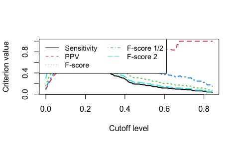

```r
data(Net)
data(Net_inf_PL)

#Comparing true and inferred networks
Crit_values=NULL

#Here are the cutoff level tested
test.seq<-seq(0,max(abs(Net_inf_PL@omics_network*0.9)),length.out=200)
for(u in test.seq){
    Crit_values<-rbind(Crit_values,Patterns::compare(Net,Net_inf_PL,u))
}
matplot(test.seq,Crit_values,type="l",ylab="Criterion value",xlab="Cutoff level",lwd=2)
legend(x="topleft", legend=colnames(Crit_values), lty=1:5,col=1:5,ncol=2,cex=.9)
```

We switch to data that were derived from the inferrence of a real biological network and try to detect the optimal cutoff value: the best cutoff value for a network to fit a scale free network. The `cutoff` was validated only single group cascade networks (number of actors groups = number of timepoints) and for genes dataset. Instead of the `cutoff` function, manual curation or the stability selection or the selectboost algorithm should be used.

```r
data("networkCascade")
set.seed(1)
cutoff(networkCascade)
```

```
#> [1] "This computation may be long"
#> [1] "1/10"
#> [1] "2/10"
#> [1] "3/10"
#> [1] "4/10"
#> [1] "5/10"
#> [1] "6/10"
#> [1] "7/10"
#> [1] "8/10"
#> [1] "9/10"
#> [1] "10/10"
#>  [1] 0.000 0.007 0.423 0.388 0.236 0.631 0.952 0.976 0.825 0.362
#> $p.value
#>  [1] 0.000 0.007 0.423 0.388 0.236 0.631 0.952 0.976 0.825 0.362
#>
#> $p.value.inter
#>  [1] -0.04643835  0.14848083  0.28125541  0.36247646  0.33538710  0.60021707
#>  [7]  0.92531630  0.98522398  0.79881816  0.37310221
#>
#> $sequence
#>  [1] 0.00000000 0.04444444 0.08888889 0.13333333 0.17777778 0.22222222
#>  [7] 0.26666667 0.31111111 0.35555556 0.40000000
```

```r
analyze_network(networkCascade,nv=0.133)
```

```
#>     node betweenness degree    output  closeness
#> 1      1           0      3 0.6442821  2.5337730
#> 2      2           8      4 1.3784717  5.4211261
#> 3      3           0      6 1.3308218  6.1428682
#> 4      4           0      9 1.7531528 19.4060065
#> 5      5           0      2 0.6400128  2.5169831
#> 6      6           0      1 0.2725100  3.4520368
#> 7      7           0      0 0.0000000  0.0000000
#> 8      8           0      1 0.1483077 10.4595738
#> 9      9           4      4 0.7969945  3.4810740
#> 10    10          20      7 1.3485173  6.0949803
#> 11    11           0      4 0.8054122 16.2236448
#> 12    12           0     11 2.4624877 10.7417814
#> 13    13           0      0 0.0000000  0.0000000
#> 14    14           0      1 0.1882265  3.8504312
```

[output cut: 88 more lines]

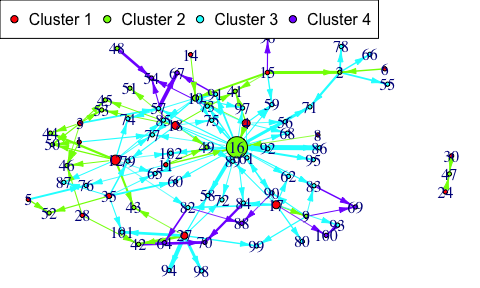

```r
data(Selection)
plot(networkCascade,nv=0.133, gr=Selection@group)
```

### Perform gene selection

Import data.

```r
library(Patterns)
library(CascadeData)
data(micro_S)
micro_S<-as.omics_array(micro_S,time=c(60,90,210,390),subject=6,gene_ID=rownames(micro_S))
data(micro_US)
micro_US<-as.omics_array(micro_US,time=c(60,90,210,390),subject=6,gene_ID=rownames(micro_US))
```

Select early genes (t1 or t2):

```r
Selection1<-Patterns::geneSelection(x=micro_S,y=micro_US,20,wanted.patterns=rbind(c(0,1,0,0),c(1,0,0,0),c(1,1,0,0)))
```

Section genes with first significant differential expression at t1:

```r
Selection2<-geneSelection(x=micro_S,y=micro_US,20,peak=1)
```

Section genes with first significant differential expression at t2:

```r
Selection3<-geneSelection(x=micro_S,y=micro_US,20,peak=2)
```

```r
Selection4<-geneSelection(x=micro_S,y=micro_US,50,
wanted.patterns=rbind(c(0,0,1,0),c(0,0,0,1),c(1,1,0,0)))
```

Merge those selections:

```r
Selection<-unionOmics(Selection1,Selection2)
Selection<-unionOmics(Selection,Selection3)
Selection<-unionOmics(Selection,Selection4)
head(Selection)
```

```
#> $omicsarray
#>                    US60       US90      US210
#> 210226_at    0.82417544  0.9166931  0.7310784
#> 233516_s_at -0.27395188 -2.3695246  0.6511830
#> 202081_at    0.60477249  0.6599672 -0.1884742
#> 236719_at   -2.07284086 -0.3123747  0.1792494
#> 236019_at   -0.08175065 -0.3699708 -0.4315901
#> 1563563_at  -1.44513486  1.6869516 -0.4297297
#>
#> $name
#> [1] "210226_at"   "233516_s_at" "202081_at"   "236719_at"   "236019_at"
#> [6] "1563563_at"
#>
#> $gene_ID
#> [1] "210226_at"   "233516_s_at" "202081_at"   "236719_at"   "236019_at"
#> [6] "1563563_at"
#>
#> $group
#> [1] 1 2 1 1 1 1
#>
#> $start_time
#> [1] 1 2 1 1 1 1
#>
#> $time
#> [1]  60  90 210 390
#>
#> $subject
#> [1] 6
```

Summarize the final selection:

```r
summary(Selection)
```

```
#>       US60               US90               US210             US390
#>  Min.   :-2.76841   Min.   :-2.369525   Min.   :-1.6147   Min.   :-2.60480
#>  1st Qu.:-0.18028   1st Qu.:-0.181425   1st Qu.: 0.1985   1st Qu.:-0.03884
#>  Median : 0.05675   Median :-0.001924   Median : 0.9886   Median : 0.31766
#>  Mean   : 0.05764   Mean   : 0.278275   Mean   : 0.9611   Mean   : 0.26428
#>  3rd Qu.: 0.22438   3rd Qu.: 0.664063   3rd Qu.: 1.6918   3rd Qu.: 0.57117
#>  Max.   : 2.86440   Max.   : 4.284675   Max.   : 3.6727   Max.   : 2.54704
#>       US60              US90              US210              US390
#>  Min.   :-2.7932   Min.   :-2.49245   Min.   :-1.21606   Min.   :-1.74407
#>  1st Qu.:-0.5547   1st Qu.:-0.01944   1st Qu.: 0.07966   1st Qu.:-0.26548
#>  Median :-0.3089   Median : 0.14977   Median : 0.72019   Median : 0.03616
#>  Mean   :-0.2917   Mean   : 0.33720   Mean   : 0.73063   Mean   : 0.06753
#>  3rd Qu.:-0.1725   3rd Qu.: 0.48744   3rd Qu.: 1.26164   3rd Qu.: 0.32496
#>  Max.   : 2.0267   Max.   : 3.37588   Max.   : 3.87950   Max.   : 2.83321
#>       US60               US90             US210             US390
#>  Min.   :-2.94444   Min.   :-0.9721   Min.   :-1.9349   Min.   :-3.8418
#>  1st Qu.:-0.23136   1st Qu.:-0.1027   1st Qu.: 0.3254   1st Qu.:-0.1592
#>  Median :-0.04761   Median : 0.2548   Median : 1.2512   Median : 0.1538
#>  Mean   : 0.22115   Mean   : 0.6479   Mean   : 1.0485   Mean   : 0.1219
#>  3rd Qu.: 0.33157   3rd Qu.: 1.0737   3rd Qu.: 1.8513   3rd Qu.: 0.6268
#>  Max.   : 3.31723   Max.   : 4.3604   Max.   : 4.4860   Max.   : 1.9886
#>       US60               US90              US210              US390
#>  Min.   :-2.85438   Min.   :-0.90355   Min.   :-0.83324   Min.   :-0.96834
#>  1st Qu.:-0.06031   1st Qu.:-0.08464   1st Qu.: 0.07605   1st Qu.: 0.01569
#>  Median : 0.03601   Median : 0.17135   Median : 0.52176   Median : 0.17370
#>  Mean   : 0.14593   Mean   : 0.41929   Mean   : 0.62446   Mean   : 0.23854
#>  3rd Qu.: 0.24568   3rd Qu.: 0.75565   3rd Qu.: 1.07821   3rd Qu.: 0.45189
#>  Max.   : 1.82903   Max.   : 3.60640   Max.   : 2.27744   Max.   : 1.90880
#>       US60               US90              US210             US390
#>  Min.   :-1.38002   Min.   :-2.94444   Min.   :-1.0271   Min.   :-1.3636
#>  1st Qu.:-0.19910   1st Qu.:-0.01758   1st Qu.: 0.1459   1st Qu.:-0.1386
#>  Median :-0.07962   Median : 0.16080   Median : 0.7430   Median : 0.1492
#>  Mean   : 0.12972   Mean   : 0.37123   Mean   : 0.7972   Mean   : 0.1271
#>  3rd Qu.: 0.26113   3rd Qu.: 0.61933   3rd Qu.: 1.3922   3rd Qu.: 0.4825
#>  Max.   : 2.31074   Max.   : 3.24454   Max.   : 3.6213   Max.   : 1.5979
#>       US60               US90              US210             US390
#>  Min.   :-1.79176   Min.   :-3.20791   Min.   :-1.4716   Min.   :-1.95883
#>  1st Qu.:-0.09822   1st Qu.:-0.03963   1st Qu.: 0.1292   1st Qu.:-0.04786
#>  Median : 0.03378   Median : 0.28261   Median : 0.8392   Median : 0.22472
#>  Mean   : 0.27978   Mean   : 0.52529   Mean   : 0.7903   Mean   : 0.21171
#>  3rd Qu.: 0.33548   3rd Qu.: 1.03256   3rd Qu.: 1.4416   3rd Qu.: 0.42511
#>  Max.   : 3.16035   Max.   : 3.19975   Max.   : 2.8027   Max.   : 2.14903
```

Plot the final selection:

```r
plot(Selection)
```

This process could be improved by retrieve a real gene_ID using the `bitr` function of the `ClusterProfiler` package or by performing independent filtering using `jetset` package to only keep at most only probeset (the best one, if there is one good enough) per gene_ID.